# Chapter 3

```r
library(sf)
library(terra)
library(dplyr)
library(spData)
data(us_states)
data(us_states_df)
```

E1. Create a new object called `us_states_name` that contains only the `NAME` column from the `us_states` object using either base R (`[`) or tidyverse (`select()`) syntax. What is the class of the new object and what makes it geographic?

```r
us_states_name <- us_states[, "NAME"]
class(us_states_name)
```

```
[1] "sf"         "data.frame"
```

E2. Select columns from the `us_states` object which contain population data. Obtain the same result using a different command (bonus: try to find three ways of obtaining the same result). Hint: try to use helper functions, such as `contains` or `matches` from **dplyr** (see `?contains`).

```r
# E2
us_states_pop1 <- us_states[, c("total_pop_10", "total_pop_15")]

us_states_pop1
```

```
Simple feature collection with 49 features and 2 fields
Geometry type: MULTIPOLYGON
Dimension:     XY
Bounding box:  xmin: -124.7042 ymin: 24.55868 xmax: -66.9824 ymax: 49.38436
Geodetic CRS:  NAD83
First 10 features:
   total_pop_10 total_pop_15
1       4712651      4830620
2       6246816      6641928
3       4887061      5278906
4       3545837      3593222
5      18511620     19645772
6       9468815     10006693
7       1526797      1616547
8       6417398      6568645
9       2809329      2892987
10      4429940      4625253
                         geometry
1  MULTIPOLYGON (((-88.20006 3...
2  MULTIPOLYGON (((-114.7196 3...
3  MULTIPOLYGON (((-109.0501 4...
4  MULTIPOLYGON (((-73.48731 4...
5  MULTIPOLYGON (((-81.81169 2...
6  MULTIPOLYGON (((-85.60516 3...
7  MULTIPOLYGON (((-116.916 45...
8  MULTIPOLYGON (((-87.52404 4...
9  MULTIPOLYGON (((-102.0517 4...
10 MULTIPOLYGON (((-92.01783 2...
```

```r
us_states |> dplyr::select(total_pop_10, total_pop_15)
```

```
Simple feature collection with 49 features and 2 fields
Geometry type: MULTIPOLYGON
Dimension:     XY
Bounding box:  xmin: -124.7042 ymin: 24.55868 xmax: -66.9824 ymax: 49.38436
Geodetic CRS:  NAD83
First 10 features:
   total_pop_10 total_pop_15                       geometry
1       4712651      4830620 MULTIPOLYGON (((-88.20006 3...
2       6246816      6641928 MULTIPOLYGON (((-114.7196 3...
3       4887061      5278906 MULTIPOLYGON (((-109.0501 4...
4       3545837      3593222 MULTIPOLYGON (((-73.48731 4...
5      18511620     19645772 MULTIPOLYGON (((-81.81169 2...
6       9468815     10006693 MULTIPOLYGON (((-85.60516 3...
7       1526797      1616547 MULTIPOLYGON (((-116.916 45...
8       6417398      6568645 MULTIPOLYGON (((-87.52404 4...
9       2809329      2892987 MULTIPOLYGON (((-102.0517 4...
10      4429940      4625253 MULTIPOLYGON (((-92.01783 2...
```

E3. Find all states with the following characteristics (bonus find *and* plot them):

- Belong to the Midwest region.

```r
# E3
us_states_midwest <- us_states[us_states$REGION=="Midwest",]
plot(st_geometry(us_states_midwest))
```

```r
#E3
plot(st_geometry(us_states |>
  filter(REGION == "Midwest")))
```

- Belong to the West region, have an area below 250,000 km<sup>2</sup> *and* in 2015 a population greater than 5,000,000 residents (hint: you may need to use the function `units::set_units()` or `as.numeric()`).

```r
# E3
us_states_west <- us_states[us_states$REGION=="West",]
us_states_west <- us_states_west[us_states_west$AREA < units::set_units(250000, "km^2"), ]
us_states_west <- us_states_west[us_states_west$total_pop_15 > 5000000, ]
us_states_west
plot(st_geometry(us_states_west))
```

- Belong to the South region, had an area larger than 150,000 km<sup>2</sup> or a total population in 2015 larger than 7,000,000 residents.

```r
us_states_south <- us_states |> filter(REGION=="South", AREA > units::set_units(150000, "km^2") | total_pop_15 > 7000000)
plot(st_geometry(us_states_south))
```

E4. What was the total population in 2015 in the `us_states` dataset? What was the minimum and maximum total population in 2015?

```r
#E4
us_states |> summarize(total_pop = sum(total_pop_15),
                       min_pop = min(total_pop_15),
                       max_pop = max(total_pop_15))
```

E5. How many states are there in each region?

E6. What was the minimum and maximum total population in 2015 in each region? What was the total population in 2015 in each region?

```r
#E6
summarize(group_by(us_states, REGION),
          min_pop=min(total_pop_15),
          max_pop=max(total_pop_15),
          tot_pop=sum(total_pop_15))
```

E7. Add variables from `us_states_df` to `us_states`, and create a new object called `us_states_stats`. What function did you use and why? Which variable is the key in both datasets? What is the class of the new object?

```r
#E7
us_states_stats <- us_states |>
  left_join(us_states_df, by = c("NAME"="state"))
class(us_states_stats)
```

E8. `us_states_df` has two more rows than `us_states`. How can you find them? (hint: try to use the `dplyr::anti_join()` function)

```r
#E8
dplyr::anti_join(us_states_df, st_drop_geometry(us_states),
                 by = c("state" = "NAME"))
```

| state | median_income_10 | median_income_15 | poverty_level_10 | poverty_level_15 |
| --- | --- | --- | --- | --- |
| Alaska | 29509 | 31455 | 64245 | 72957 |
| Hawaii | 29945 | 31051 | 124627 | 153944 |

E9. What was the population density in 2015 in each state? What was the population density in 2010 in each state?

```r
us_pop_density_15
```

```
Units: [1/km^2]
 [1]   36.127786   22.493565   19.582469  276.900364  130.059657
 [6]   65.520897    7.466293   70.141565   13.579734   37.804767
[11]  320.676491   24.794153   33.452701    2.664447    9.773012
[16]  439.210687  154.660883    3.939560   21.272605  109.001118
[21]   59.052713    4.220871   38.589593   25.199068   29.474967
[26]   21.484573   93.768733  178.788485 3633.263718   88.180609
[31]   21.225799   42.096925   15.541438  220.887166   65.515059
[36]   24.147135    9.334115   55.114234    6.618638   76.182958
[41]  108.134796   15.672536  384.119309   59.567250   13.205593
[46]   78.332684   39.817723   39.613278    2.288421
```

or

```r
us_states2$pop_dens_15
```

```
Units: [1/km^2]
 [1]   36.127786   22.493565   19.582469  276.900364  130.059657
 [6]   65.520897    7.466293   70.141565   13.579734   37.804767
[11]  320.676491   24.794153   33.452701    2.664447    9.773012
[16]  439.210687  154.660883    3.939560   21.272605  109.001118
[21]   59.052713    4.220871   38.589593   25.199068   29.474967
[26]   21.484573   93.768733  178.788485 3633.263718   88.180609
[31]   21.225799   42.096925   15.541438  220.887166   65.515059
[36]   24.147135    9.334115   55.114234    6.618638   76.182958
[41]  108.134796   15.672536  384.119309   59.567250   13.205593
[46]   78.332684   39.817723   39.613278    2.288421
```

E10. How much has population density changed between 2010 and 2015 in each state? Calculate the change in percentages and map them.

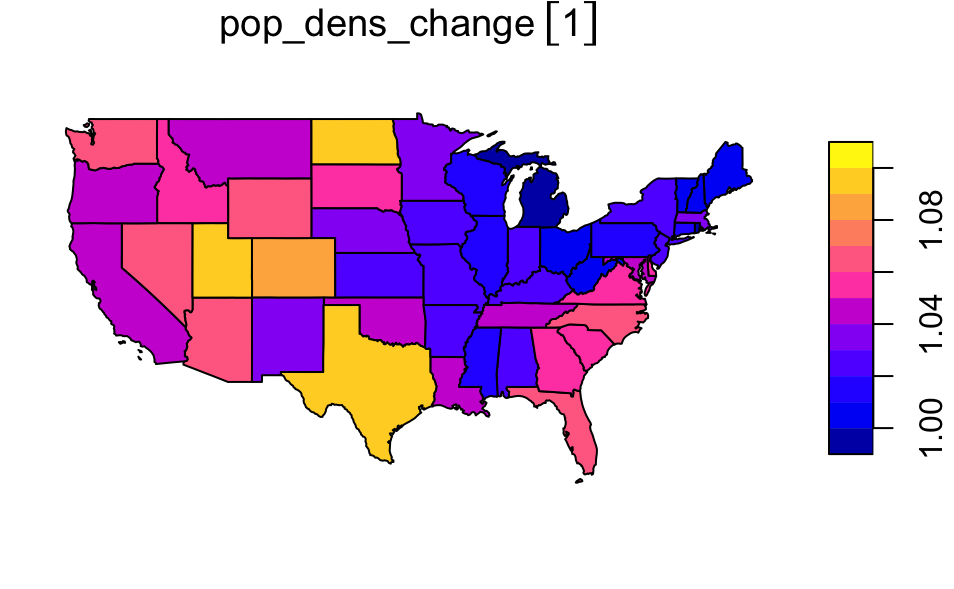

```r
#E10
us_states2$pop_dens_change <-
  us_states2$pop_dens_15 / us_states2$pop_dens_10

plot(us_states2[, "pop_dens_change"] )
```

E11. Change the columns’ names in `us_states` to lowercase. (Hint: helper functions - `tolower()` and `colnames()` may help.)

```r
us_states |>
  setNames(tolower(colnames(us_states)))
```

```
Simple feature collection with 49 features and 6 fields
Geometry type: MULTIPOLYGON
Dimension:     XY
Bounding box:  xmin: -124.7042 ymin: 24.55868 xmax: -66.9824 ymax: 49.38436
Geodetic CRS:  NAD83
First 10 features:
   geoid        name   region             area total_pop_10
1     01     Alabama    South 133709.27 [km^2]      4712651
2     04     Arizona     West 295281.25 [km^2]      6246816
3     08    Colorado     West 269573.06 [km^2]      4887061
4     09 Connecticut Norteast  12976.59 [km^2]      3545837
5     12     Florida    South 151052.01 [km^2]     18511620
6     13     Georgia    South 152725.21 [km^2]      9468815
7     16       Idaho     West 216512.66 [km^2]      1526797
8     18     Indiana  Midwest  93648.40 [km^2]      6417398
9     20      Kansas  Midwest 213037.08 [km^2]      2809329
10    22   Louisiana    South 122345.76 [km^2]      4429940
   total_pop_15                       geometry
1       4830620 MULTIPOLYGON (((-88.20006 3...
2       6641928 MULTIPOLYGON (((-114.7196 3...
3       5278906 MULTIPOLYGON (((-109.0501 4...
4       3593222 MULTIPOLYGON (((-73.48731 4...
5      19645772 MULTIPOLYGON (((-81.81169 2...
6      10006693 MULTIPOLYGON (((-85.60516 3...
7       1616547 MULTIPOLYGON (((-116.916 45...
8       6568645 MULTIPOLYGON (((-87.52404 4...
9       2892987 MULTIPOLYGON (((-102.0517 4...
10      4625253 MULTIPOLYGON (((-92.01783 2...
```

or

```r
us_states %>%
  setNames(tolower(colnames(.)))
```

```
Simple feature collection with 49 features and 6 fields
Geometry type: MULTIPOLYGON
Dimension:     XY
Bounding box:  xmin: -124.7042 ymin: 24.55868 xmax: -66.9824 ymax: 49.38436
Geodetic CRS:  NAD83
First 10 features:
   geoid        name   region             area total_pop_10
1     01     Alabama    South 133709.27 [km^2]      4712651
2     04     Arizona     West 295281.25 [km^2]      6246816
3     08    Colorado     West 269573.06 [km^2]      4887061
4     09 Connecticut Norteast  12976.59 [km^2]      3545837
5     12     Florida    South 151052.01 [km^2]     18511620
6     13     Georgia    South 152725.21 [km^2]      9468815
7     16       Idaho     West 216512.66 [km^2]      1526797
8     18     Indiana  Midwest  93648.40 [km^2]      6417398
9     20      Kansas  Midwest 213037.08 [km^2]      2809329
10    22   Louisiana    South 122345.76 [km^2]      4429940
   total_pop_15                       geometry
1       4830620 MULTIPOLYGON (((-88.20006 3...
2       6641928 MULTIPOLYGON (((-114.7196 3...
3       5278906 MULTIPOLYGON (((-109.0501 4...
4       3593222 MULTIPOLYGON (((-73.48731 4...
5      19645772 MULTIPOLYGON (((-81.81169 2...
6      10006693 MULTIPOLYGON (((-85.60516 3...
7       1616547 MULTIPOLYGON (((-116.916 45...
8       6568645 MULTIPOLYGON (((-87.52404 4...
9       2892987 MULTIPOLYGON (((-102.0517 4...
10      4625253 MULTIPOLYGON (((-92.01783 2...
```

```r
?setNames
```

E12. Using `us_states` and `us_states_df` create a new object called `us_states_sel`. The new object should have only two variables - `median_income_15` and `geometry`. Change the name of the `median_income_15` column to `Income`.

[output not shown]

[output cut: 41 more lines]

```r
us_states_sel <- left_join(us_states, us_states_df, by = c("NAME" = "state"))
us_states_sel <- dplyr::select(us_states_sel, Income=median_income_15)
us_states_sel
```

```
Simple feature collection with 49 features and 1 field
Geometry type: MULTIPOLYGON
Dimension:     XY
Bounding box:  xmin: -124.7042 ymin: 24.55868 xmax: -66.9824 ymax: 49.38436
Geodetic CRS:  NAD83
First 10 features:
   Income                       geometry
1   22890 MULTIPOLYGON (((-88.20006 3...
2   26156 MULTIPOLYGON (((-114.7196 3...
3   30752 MULTIPOLYGON (((-109.0501 4...
4   33226 MULTIPOLYGON (((-73.48731 4...
5   24654 MULTIPOLYGON (((-81.81169 2...
6   25588 MULTIPOLYGON (((-85.60516 3...
7   23558 MULTIPOLYGON (((-116.916 45...
8   25834 MULTIPOLYGON (((-87.52404 4...
9   27315 MULTIPOLYGON (((-102.0517 4...
10  24014 MULTIPOLYGON (((-92.01783 2...
```

or

```r
us_states_sel <- us_states |>
  left_join(us_states_df, by = c("NAME" = "state")) |>
  dplyr::select(Income = median_income_15)
```

E13. Calculate the change in the number of residents living below the poverty level between 2010 and 2015 for each state. (Hint: See ?us_states_df for documentation on the poverty level columns.) Bonus: Calculate the change in the *percentage* of residents living below the poverty level in each state.